# PES University, Bangalore Established under the Karnataka Act No. 16 of 2013

### Solution 2

1. Consider the data. Which type of ANOVA can Scully use? (Justify why the particular test)
2. What function(s) could have been used by Scully for the ANOVA if he uses the R programming language?
3. What does the output of this/these functions tell Scully? (Specify hypotheses and what each column in the summary of the output means considering 5% significance)
4. Hitchcock thinks that Scully has missed a task which completes the ANOVA test. What should Scully have thought of? *Hint:* Philosophically, a hypothesis is a proposition made as a basis for reasoning, without any assumption of its truth.

We will be using Ch7Demo2.csv for ANOVA as the given case isn’t probably the best use case for two way ANOVA.  
Using two way ANOVA here as we have different levels of 2 factors(Discount and Location) that may or may not cause variation in response variable (Sales). We want to understand the impact of both factors simultaneously on sales.

```r
two.way<-aov(Sales ~ Location*Discount, data=data)
summary(two.way)
```

```
##                    Df Sum Sq Mean Sq F value   Pr(>F)
## Location            1    7.0     7.0   0.444   0.5066
## Discount            2 1240.3   620.2  39.280 1.06e-13 ***
## Location:Discount   2   84.8    42.4   2.686   0.0725 .
## Residuals         114 1799.9    15.8
## ---
## Signif. codes:  0 '***' 0.001 '**' 0.01 '*' 0.05 '.' 0.1 ' ' 1
```

P value for location 0.5066, so it is not statistically significant(we fail to reject null hypothesis saying locations are impactful on sales of a product) whereas for discounts th ep value is 1.06e-13 which is statistically significant (we reject null hypothesis saying discount rates have influence on sales). The p value for interaction effect is 0.0725 and is not significant at 5% level. That is, only discount is statistically significant at alpha = 0.05.

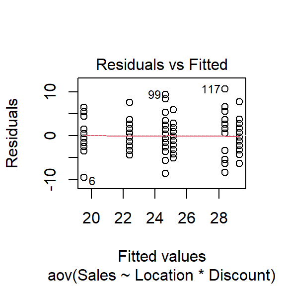

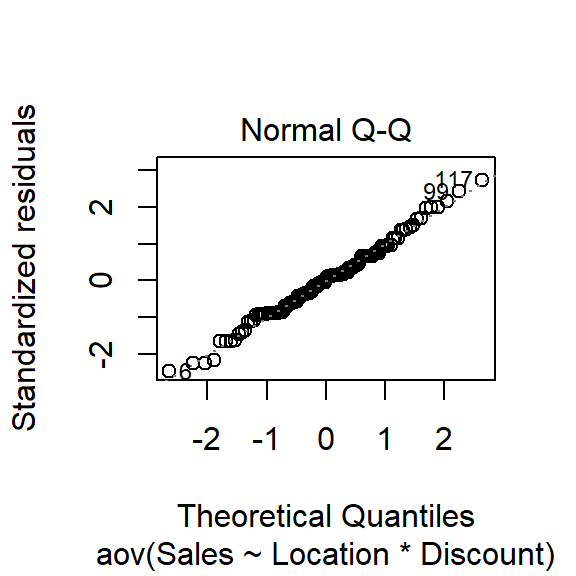

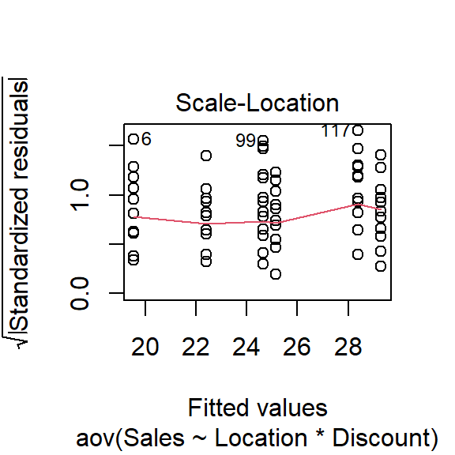

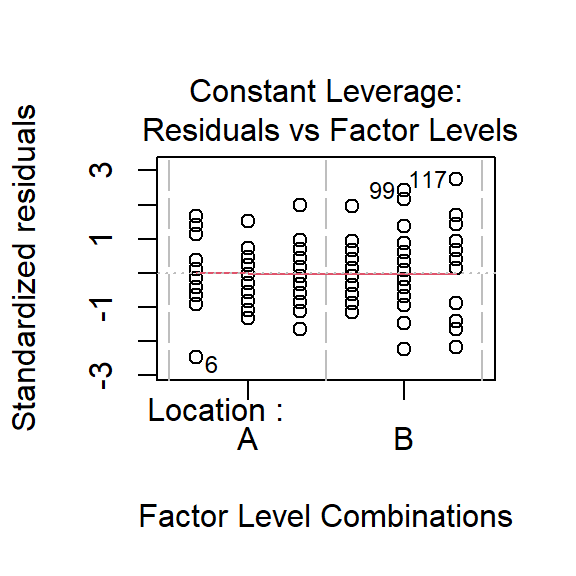

```r
par(mfrow=c(1,1))
plot(two.way)
```

```r
par(mfrow=c(1,1))
```

The red line representing the mean of the residuals should be horizontal and centered on zero (or on one, in the scale-location plot), meaning that there are no large outliers that would cause bias in the model.  
The normal Q-Q plot plots a regression between the theoretical residuals of a perfectly-homoscedastic model and the actual residuals of your model, so the closer to a slope of 1 this is the better. This Q-Q plot is very close, with only a bit of deviation.  
From these diagnostic plots we can say that the model fits the assumption of homoscedasticity.

### Solution 3

Hitchcock also wanted to compare the number of items collected for each pair of Person of Interest and priority. He decided to follow the common practice of doing a **Tukey’s HSD** . The [Tukey’s Honestly-Significant-Difference](https://www.real-statistics.com/one-way-analysis-of-variance-anova/unplanned-comparisons/tukey-hsd/)[TukeyHSD] test lets us see which groups are different from one another.

What insights did Hitchcock gain after doing the Tukey’s HSD? (The `TukeyHSD` function can be used to do this test and the output of this function can be represented graphically using the `plot` function.)

```r
TukeyHSD(two.way, conf.level=.95)
```

```
##   Tukey multiple comparisons of means
##     95% family-wise confidence level
##
## Fit: aov(formula = Sales ~ Location * Discount, data = data)
##
## $Location
##          diff        lwr      upr    p adj
## B-A 0.4833333 -0.9537696 1.920436 0.506593
##
## $Discount
##      diff      lwr      upr    p adj
## B-A 3.925 1.815098 6.034902 6.75e-05
## C-A 7.875 5.765098 9.984902 0.00e+00
## C-B 3.950 1.840098 6.059902 6.04e-05
##
## $`Location:Discount`
##          diff        lwr      upr     p adj
## B:A-A:A  2.85 -0.7923401  6.49234 0.2157916
## A:B-A:A  5.60  1.9576599  9.24234 0.0002778
## B:B-A:A  5.10  1.4576599  8.74234 0.0012489
## A:C-A:A  9.75  6.1076599 13.39234 0.0000000
## B:C-A:A  8.85  5.2076599 12.49234 0.0000000
## A:B-B:A  2.75 -0.8923401  6.39234 0.2511868
## B:B-B:A  2.25 -1.3923401  5.89234 0.4758459
## A:C-B:A  6.90  3.2576599 10.54234 0.0000036
## B:C-B:A  6.00  2.3576599  9.64234 0.0000777
## B:B-A:B -0.50 -4.1423401  3.14234 0.9986826
## A:C-A:B  4.15  0.5076599  7.79234 0.0157766
## B:C-A:B  3.25 -0.3923401  6.89234 0.1090063
## A:C-B:B  4.65  1.0076599  8.29234 0.0043930
## B:C-B:B  3.75  0.1076599  7.39234 0.0396666
## B:C-A:C -0.90 -4.5423401  2.74234 0.9796187
```

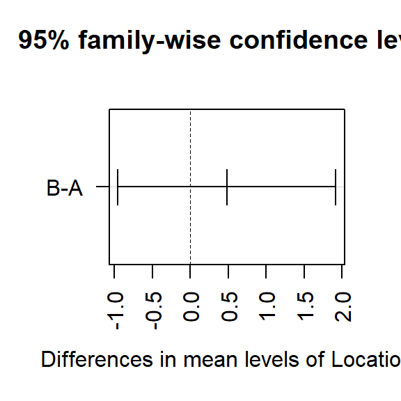

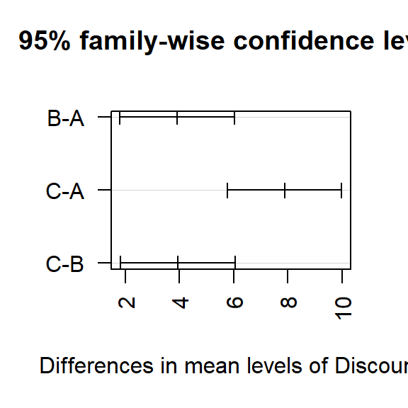

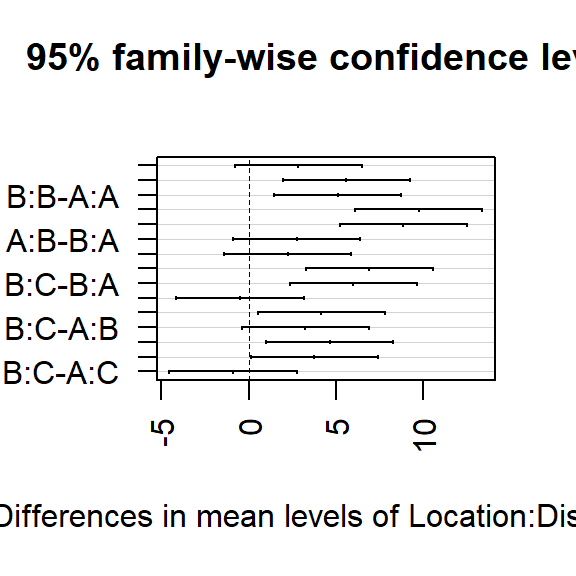

```r
plot(TukeyHSD(two.way, conf.level=.95), las = 2)
```

Tukey HSD - Any two treatments that mean having a difference more than honestly significant difference are said to be significantly different, otherwise not.  
For location, p = 0.506593 (> alpha) means the group levels are not a significant factor towards the sales (there is no significant difference on sales whether it was bought at location A or location B)  
For discount, all p values << 0.05, indicating that there is enough evidence to conclude that the group means are not equal. So there is significant difference on sales based on a particular discount value (A,B,C).  
For Location:Discount, the combination of Location 1: Discount 1 vs Location 2: Discount 2 is statistically insignificant for these pairs –

```r
          p adj
B:A-A:A 0.2157916
A:B-B:A 0.2511868
B:B-B:A 0.4758459
B:B-A:B 0.9986826
B:C-A:B 0.1090063
B:C-A:C 0.9796187
```